# R Notebook

```r
# # Required Packages
packages = c('quantmod','car','forecast','tseries','FinTS', 'rugarch','utf8','ggplot2')
#
# # Install all Packages with Dependencies
#install.packages(packages, dependencies = TRUE)
#
# # Load all Packages
lapply(packages, require, character.only = TRUE)
```

```
  method            from
  as.zoo.data.frame zoo
    ‘tseries’ version: 0.10-55

    ‘tseries’ is a package for time series analysis and computational finance.

    See ‘library(help="tseries")’ for details.
```

[output not shown]

```r
##
# 0.1. Fetch Single Stock/Index Data
getSymbols(Symbols = 'SBIN.NS',
           src = 'yahoo',
           from = as.Date('2018-01-01'),
           to = as.Date('2023-12-31'),
           periodicity = 'daily')
```

```
[1] "SBIN.NS"
```

```r
stock_price = na.omit(SBIN.NS$SBIN.NS.Adjusted) # Adjusted Closing Price
class(stock_price) # xts (Time-Series) Object
```

```
[1] "xts" "zoo"
```

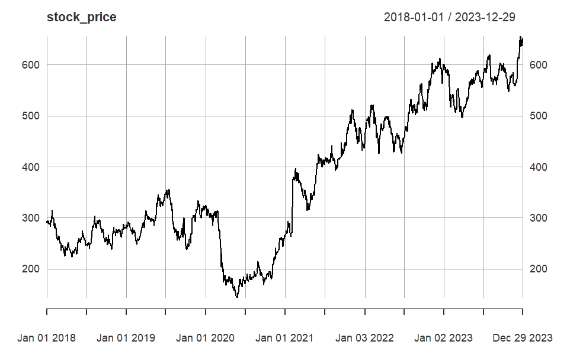

```r
stock_ret = na.omit(diff(log(stock_price))) # Stock Returns
plot(stock_price)
```

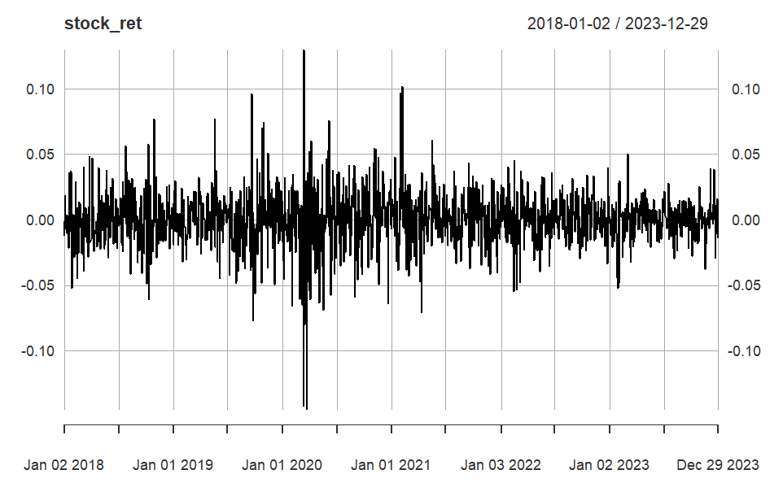

```r
plot(stock_ret)
```

```r
# Augmented Dickey-Fuller (ADF) Test for Stationarity with Stock Data

adf_test_stk_price = adf.test(stock_price); adf_test_stk_price  # Inference : Stock price Time-Series is Non-Stationary
```

```
    Augmented Dickey-Fuller Test

data:  stock_price
Dickey-Fuller = -2.3339, Lag order = 11, p-value = 0.437
alternative hypothesis: stationary
```

```r
adf_test_stk_ret = adf.test(stock_ret); adf_test_stk_ret # Inference : Stock Difference Time-Series is Stationary
```

```
    Augmented Dickey-Fuller Test

data:  stock_ret
Dickey-Fuller = -9.6426, Lag order = 11, p-value = 0.01
alternative hypothesis: stationary
```

Objective: To assess the stationarity of the stock price and stock return time series.

Analysis: In this analysis, the Augmented Dickey-Fuller (ADF) test was employed to determine the stationarity of two time series: stock prices and stock returns. The ADF test is a common statistical test used to identify whether a given time series is stationary or non-stationary. A stationary time series is one whose statistical properties such as mean, variance, and autocorrelation are constant over time. For both tests, a lag order of 11 was used.

Result: - For the stock price time series, the Dickey-Fuller statistic is -2.3339 with a p-value of 0.437. Given the high p-value (greater than the typical significance level of 0.05), we fail to reject the null hypothesis, suggesting that the stock price time series is non-stationary. - For the stock return time series, the Dickey-Fuller statistic is -9.6426 with a p-value of 0.01. The low p-value (less than the typical significance level of 0.05) indicates that we can reject the null hypothesis, suggesting that the stock return time series is stationary.